# Puxando resultados anteriores da Mega-Sena com python (pelo site da CAIXA)

```
consultar_resultado(2435)
```

resposta:

```
{
  'concurso': 2435,                                          # número do concurso
  'data': '07/12/2021',                                      # data do sorteio
  'dezenas': ['032', '030', '036', '033', '022', '005'],     # dezenas sorteadas
  'senas': 0,                                                # número de ganhadores da sena
  'senas_premio': 0.0,                                       # prêmio pela sena
  'quinas': 46,                                              # número de ganhadores das quinas
  'quinas_premio': 46912.51,                                 # prêmio pelas quinas
  'quadras': 3051,                                           # número de ganhadores das quadras
  'quadras_premio': 1010.43                                  # prêmio pelas quadras
}
```

```python
import json
import requests
import seaborn as sns
import pandas as pd
from numpy import mean
```

```python
def consultar_resultado(concurso:int):
  url_base = 'http://www.loterias.caixa.gov.br/wps/portal/loterias/landing/megasena/!ut/p/a1/04_Sj9CPykssy0xPLMnMz0vMAfGjzOLNDH0MPAzcDbwMPI0sDBxNXAOMwrzCjA0sjIEKIoEKnN0dPUzMfQwMDEwsjAw8XZw8XMwtfQ0MPM2I02-AAzgaENIfrh-FqsQ9wNnUwNHfxcnSwBgIDUyhCvA5EawAjxsKckMjDDI9FQE-F4ca/dl5/d5/L2dBISEvZ0FBIS9nQSEh/pw/Z7_HGK818G0KO6H80AU71KG7J0072/res/id=buscaResultado/c=cacheLevelPage//p=concurso=2437?timestampAjax=1640901697542'

  url = url_base.replace('2437',str(concurso))
  resp = requests.get(url)
  parsed_resp = json.loads(resp.content)

  concurso = parsed_resp['numero']
  data = parsed_resp['dataApuracao']
  dezenas = parsed_resp['dezenasSorteadasOrdemSorteio']
  senas = parsed_resp['listaRateioPremio'][0]['numeroDeGanhadores']
  senas_premio = parsed_resp['listaRateioPremio'][0]['valorPremio']
  quinas = parsed_resp['listaRateioPremio'][1]['numeroDeGanhadores']
  quinas_premio = parsed_resp['listaRateioPremio'][1]['valorPremio']
  quadras = parsed_resp['listaRateioPremio'][2]['numeroDeGanhadores']
  quadras_premio = parsed_resp['listaRateioPremio'][2]['valorPremio']

  return {
    'concurso': concurso,
    'data': data,
    'dezenas': dezenas,
    'senas': senas,
    'senas_premio': senas_premio,
    'quinas': quinas,
    'quinas_premio': quinas_premio,
    'quadras': quadras,
    'quadras_premio': quadras_premio
  }
```

```python
consultar_resultado(2435)
```

```
{'concurso': 2435,
 'data': '07/12/2021',
 'dezenas': ['032', '030', '036', '033', '022', '005'],
 'senas': 0,
 'senas_premio': 0.0,
 'quinas': 46,
 'quinas_premio': 46912.51,
 'quadras': 3051,
 'quadras_premio': 1010.43}
```

# Importando todos os sorteios de arquivo

Rodei a requisição de todos os sorteios uma vez e salvei em arquivo pra facilitar o acesso

```python
# Pegar resultados do site da CAIXA e salvar em arquivo

# resultados_1_999 =[consultar_resultado(concurso) for concurso in range(1,1000)]
# resultados_1000_1999 =[consultar_resultado(concurso) for concurso in range(1000,2000)]
# resultados_2000_2439 =[consultar_resultado(concurso) for concurso in range(2000,2440)]

# todos_os_resultados = resultados_1_999 + resultados_1000_1999 + resultados_2000_2439
# len(todos_os_resultados)

# with open('todos_os_resultados.json', 'w') as f:
#   json.dump(todos_os_resultados, f)
```

```python
with open('todos_os_resultados.json') as f:
  todos_os_resultados = json.load(f)

[todos_os_resultados[0],todos_os_resultados[-1]]
```

```
[{'concurso': 1,
  'data': '11/03/1996',
  'dezenas': ['041', '005', '004', '052', '030', '033'],
  'senas': 0,
  'senas_premio': 0.0,
  'quinas': 17,
  'quinas_premio': 39158.92,
  'quadras': 2016,
  'quadras_premio': 330.21},
 {'concurso': 2439,
  'data': '18/12/2021',
  'dezenas': ['047', '038', '002', '034', '051', '008'],
  'senas': 0,
  'senas_premio': 0.0,
  'quinas': 46,
  'quinas_premio': 40082.94,
  'quadras': 3008,
  'quadras_premio': 875.67}]
```

## Conjuntos de sorteios:

#### Sorteios de megas da virada a partir de 2010:

```python
megas_virada = [1140,1245,1350,1455,1560,1665,1775,1890,2000,2110,2220,2330]
# resultados_megas_virada = [consultar_resultado(concurso) for concurso in megas_virada]
resultados_megas_virada = [todos_os_resultados[concurso-1] for concurso in megas_virada]
resultados_megas_virada[-3]
```

```
{'concurso': 2110,
 'data': '31/12/2018',
 'dezenas': ['025', '033', '010', '012', '018', '005'],
 'senas': 52,
 'senas_premio': 5818007.36,
 'quinas': 7688,
 'quinas_premio': 6644.73,
 'quadras': 303857,
 'quadras_premio': 240.17}
```

```python
# resultados_2021 = [consultar_resultado(concurso) for concurso in range(2331,2440)]
resultados_2021 = [todos_os_resultados[concurso-1] for concurso in range(2331,2440)]
[resultados_2021[0],resultados_2021[-1]]
```

```
[{'concurso': 2331,
  'data': '02/01/2021',
  'dezenas': ['053', '016', '011', '057', '013', '036'],
  'senas': 0,
  'senas_premio': 0.0,
  'quinas': 10,
  'quinas_premio': 50540.79,
  'quadras': 808,
  'quadras_premio': 893.57},
 {'concurso': 2439,
  'data': '18/12/2021',
  'dezenas': ['047', '038', '002', '034', '051', '008'],
  'senas': 0,
  'senas_premio': 0.0,
  'quinas': 46,
  'quinas_premio': 40082.94,
  'quadras': 3008,
  'quadras_premio': 875.67}]
```

# Contar vencedores

### Tentar estimar quais os números mais escolhidos pelos apostadores?

Contar o número de vencedores a cada vez que uma das dezenas era sorteada

```
contar_vencedores(reultados, resultado_esperado)
```

`resultados` é uma lista com resultados dos concursos de interesse  
`resultado_esperado` pode ser `'senas'`, `'quinas'` ou `'quadras'`

Retorna um dicionário em que as dezenas sorteadas são as chaves e o valor é uma lista contendo o número de vencedores para cada sorteio em que a dezena saiu ex.:

```
contar_vencedores(resultados_megas_virada, 'senas')
```

retorna:

[output not shown]

```python
def contar_vencedores(resultados, resultado_esperado = 'senas'):
  contagem = {}
  for resultado in resultados:
    if resultado[resultado_esperado]>0:
      for dezena in resultado['dezenas']:
        contagem.setdefault(dezena,[])
        contagem[dezena].append(resultado[resultado_esperado])
  return contagem
```

```python
contar_vencedores(resultados_megas_virada[2:4], 'senas')
```

```
{'004': [5],
 '036': [5, 3],
 '029': [5],
 '055': [5],
 '045': [5],
 '003': [5],
 '033': [3],
 '014': [3],
 '052': [3],
 '032': [3],
 '041': [3]}
```

```python
contar_vencedores(resultados_megas_virada[2:4], 'quadras')
```

```
{'004': [85582],
 '036': [85582, 113258],
 '029': [85582],
 '055': [85582],
 '045': [85582],
 '003': [85582],
 '033': [113258],
 '014': [113258],
 '052': [113258],
 '032': [113258],
 '041': [113258]}
```

# Frequência de aparição das dezenas

Faz a contagem de quantas vezes cada dezena foi sorteada em um conjunto de resultados

```
frequencia_das_dezenas(resultados, ordenar_por_chave, Decrescente)
```

O resultado é retornado em um dicionário com a dezena sendo a chave e a frequência sendo o valor. A ordenação pode ser pelas dezenas ou pelas frequências de aparição, em ordem crescente ou decrescente

```
frequencia_das_dezenas(resultados_2021, False, True)
```

retorna

```
{
  '025': 19,    # dezena mais sorteada em 2021
  '011': 17,    # 2ª dezena mais sorteada em 2021
  '038': 17,
  '029': 16,
  '044': 15,
  '009': 15,
  ...
}
```

```python
def frequencia_das_dezenas(resultados, ordenar_por_chave=True, Decrescente=False):
  frequencias = {}
  for resultado in resultados:
    for dezena in resultado['dezenas']:
      frequencias.setdefault(dezena,0)
      frequencias[dezena]+=1

  # Retornar ordenado pela dezena
  if(ordenar_por_chave):
    return dict(sorted(frequencias.items(), reverse=Decrescente))

  # Retornar ordenado pelas frequências
  else:
    return dict(sorted(frequencias.items(), key=lambda item: item[1], reverse=Decrescente))
```

```python
freq_dezenas_2021 = frequencia_das_dezenas(resultados_2021, False, True)
freq_dezenas_2021
```

```
{'025': 19,
 '011': 17,
 '038': 17,
 '029': 16,
 '044': 15,
 '009': 15,
 '060': 15,
 '049': 15,
 '032': 15,
 '053': 14,
 '041': 14,
 '008': 14,
 '048': 14,
 '019': 14,
 '037': 14,
 '016': 13,
 '035': 13,
 '004': 13,
 '042': 13,
 '051': 13,
 '003': 13,
 '030': 13,
 '036': 12,
 '022': 12,
 '034': 12,
 '007': 12,
 '039': 12,
 '057': 11,
 '013': 11,
 '010': 11,
 '002': 11,
 '046': 11,
 '005': 11,
 '026': 11,
 '031': 10,
 '020': 10,
 '027': 10,
 '028': 10,
 '017': 10,
 '054': 10,
 '043': 10,
 '055': 9,
 '040': 9,
 '056': 9,
 '012': 8,
 '006': 8,
 '033': 7,
 '047': 7,
 '050': 7,
 '024': 7,
 '058': 7,
 '014': 7,
 '052': 6,
 '018': 6,
 '023': 6,
 '021': 6,
 '045': 6,
 '015': 5,
 '059': 4,
 '001': 4}
```

```
[Text(0.5, 1.0, 'Frequência das dezenas em 2021'), Text(0, 0.5, 'sorteios')]
```

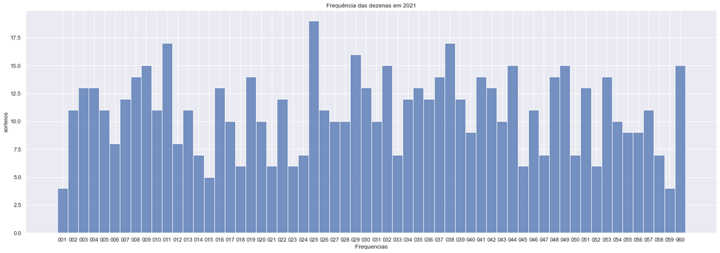

```python
dezenas_sorteadas_2021 = []
for resultado in resultados_2021:
  dezenas_sorteadas_2021 += resultado['dezenas']

df = pd.DataFrame()
df['Frequencias'] = sorted(dezenas_sorteadas_2021)
# df['Frequencias'] = [int(dezena) for dezena in sorted(dezenas_sorteadas_2021)]

sns.set(rc={'figure.figsize':(25,8.27)})
sns.histplot(x=df['Frequencias']).set(title='Frequência das dezenas em 2021', ylabel='sorteios')
```

```
[Text(0.5, 1.0, 'Frequência histórica das dezenas'), Text(0, 0.5, 'sorteios')]
```

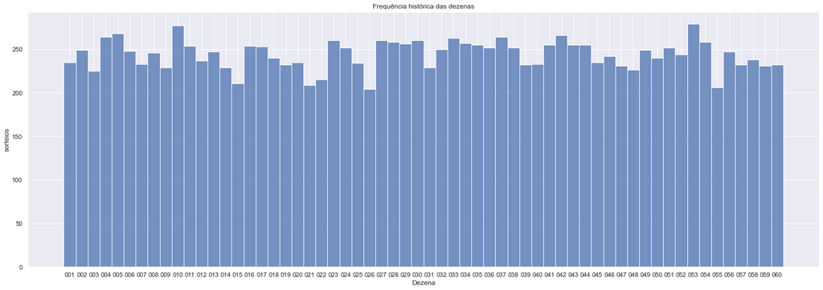

```python
todas_dezenas_sorteadas = []
for resultado in todos_os_resultados:
  todas_dezenas_sorteadas += resultado['dezenas']

df = pd.DataFrame()
df['Dezena'] = sorted(todas_dezenas_sorteadas)
# df['Dezena'] = [int(dezena) for dezena in sorted(dezenas_sorteadas_2021)]

sns.set(rc={'figure.figsize':(25,8.27)})
sns.histplot(x=df['Dezena']).set(title='Frequência histórica das dezenas', ylabel='sorteios')
```

```python
df_freq = pd.DataFrame()
df_freq['Frequencia'] = df['Dezena'].value_counts()
df_freq
```

|  | Frequencia |
| --- | --- |
| 053 | 279 |
| 010 | 277 |
| 005 | 268 |
| 042 | 266 |
| 037 | 264 |
| 004 | 264 |
| 033 | 263 |
| 023 | 260 |
| 030 | 260 |
| 027 | 260 |
| 054 | 258 |
| 028 | 258 |
| 034 | 257 |
| 029 | 256 |
| 035 | 255 |
| 044 | 255 |
| 041 | 255 |
| 043 | 255 |
| 011 | 254 |
| 016 | 254 |
| 017 | 253 |
| 038 | 252 |
| 036 | 252 |
| 051 | 252 |
| 024 | 252 |
| 032 | 250 |
| 002 | 249 |
| 049 | 249 |
| 006 | 248 |
| 056 | 247 |
| 013 | 247 |
| 008 | 246 |
| 052 | 244 |
| 046 | 242 |
| 018 | 240 |
| 050 | 240 |
| 058 | 238 |
| 012 | 237 |
| 045 | 235 |
| 001 | 235 |
| 020 | 235 |
| 025 | 234 |
| 007 | 233 |
| 040 | 233 |
| 019 | 232 |
| 060 | 232 |
| 039 | 232 |
| 057 | 232 |
| 047 | 231 |
| 059 | 231 |
| 014 | 229 |
| 031 | 229 |
| 009 | 229 |
| 048 | 226 |
| 003 | 225 |
| 022 | 215 |
| 015 | 211 |
| 021 | 209 |
| 055 | 206 |
| 026 | 204 |

```python
list(df_freq.sort_values(by=['Frequencia']).head(10).index)
```

```
['026', '055', '021', '015', '022', '003', '048', '009', '031', '014']
```

```python
list(df_freq.sort_values(by=['Frequencia'], ascending=False).head(10).index)
```

```
['053', '010', '005', '042', '037', '004', '033', '023', '030', '027']
```

### Dezenas mais sorteadas:

`['053', '010', '005', '042', '037', '004', '033', '023', '030', '027']`

### Dezemas menos sorteadas:

`['026', '055', '021', '015', '022', '003', '048', '009', '031', '014']`

# Estimar frequência de apostas em cada dezena

Tentar aproximar a frequência de apostas pela soma histórica do número de vencedores quando cada uma das dezenas foi sorteada

```
[Text(0.5, 1.0, 'Frequência histórica com que as dezenas ganharam a sena'),
```

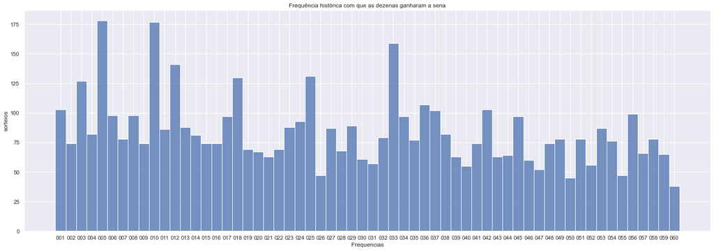

```python
dezenas_sorteadas_ganhadoras_sena = []
for resultado in todos_os_resultados:
  senas_ganhadoras = resultado['senas']
  if senas_ganhadoras>0:
    dezenas_sorteadas_ganhadoras_sena += resultado['dezenas']*senas_ganhadoras

df = pd.DataFrame()
df['Frequencias'] = sorted(dezenas_sorteadas_ganhadoras_sena)
# df['Frequencias'] = [int(dezena) for dezena in sorted(dezenas_sorteadas_2021)]

sns.set(rc={'figure.figsize':(25,8.27)})
sns.histplot(x=df['Frequencias']).set(title='Frequência histórica com que as dezenas ganharam a sena', ylabel='sorteios')
```

Parece que 5 e 10 são números em que muita gente aposta, então as chances de sairem mais vencedores quando esses números sorteados aumenta.

Históricamente 53 foi a dezena mais sorteada até hoje, mas o número de apostas vencedoras que apostaram nela é menor, provavelmente por ser uma dezena em que menos pessoas apostam

```
[Text(0.5, 1.0, 'Frequência histórica com que as dezenas ganharam a quina'),
```

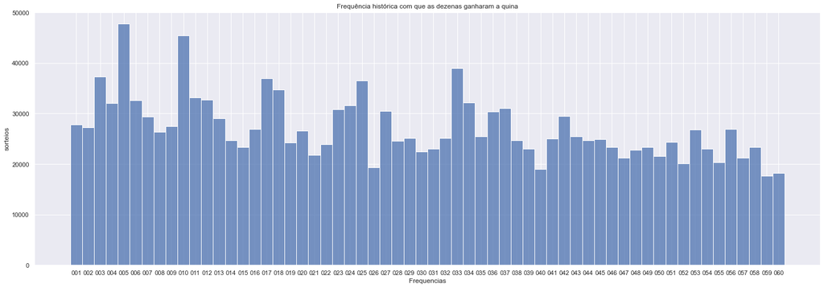

```python
dezenas_sorteadas_ganhadoras_quina = []
for resultado in todos_os_resultados:
  quinas_ganhadoras = resultado['quinas']
  if quinas_ganhadoras>0:
    dezenas_sorteadas_ganhadoras_quina += resultado['dezenas']*quinas_ganhadoras

df = pd.DataFrame()
df['Frequencias'] = sorted(dezenas_sorteadas_ganhadoras_quina)
# df['Frequencias'] = [int(dezena) for dezena in sorted(dezenas_sorteadas_2021)]

sns.set(rc={'figure.figsize':(25,8.27)})
sns.histplot(x=df['Frequencias']).set(title='Frequência histórica com que as dezenas ganharam a quina', ylabel='sorteios')
```

```
[Text(0.5, 1.0, 'Frequência histórica com que as dezenas ganharam a quadra'),
```

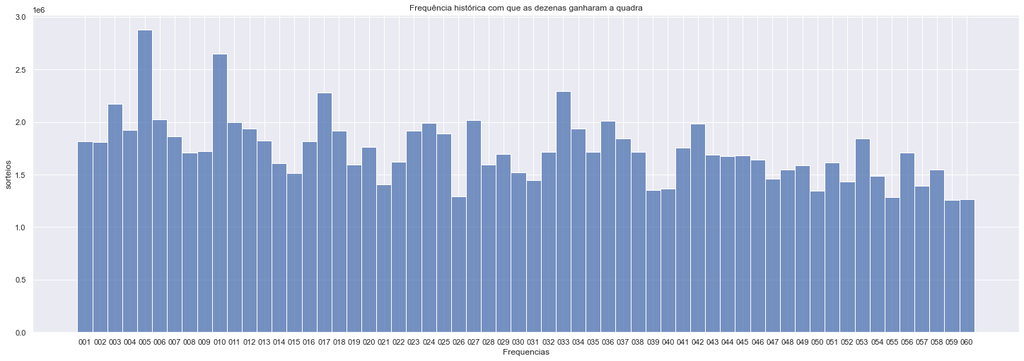

```python
dezenas_sorteadas_ganhadoras_quadra = []
for resultado in todos_os_resultados:
  quadras_ganhadoras = resultado['quadras']
  if quadras_ganhadoras>0:
    dezenas_sorteadas_ganhadoras_quadra += resultado['dezenas']*quadras_ganhadoras

df = pd.DataFrame()
df['Frequencias'] = sorted(dezenas_sorteadas_ganhadoras_quadra)
# df['Frequencias'] = [int(dezena) for dezena in sorted(dezenas_sorteadas_2021)]

sns.set(rc={'figure.figsize':(25,8.27)})
sns.histplot(x=df['Frequencias']).set(title='Frequência histórica com que as dezenas ganharam a quadra', ylabel='sorteios')
```

# Média de vencedores por dezena sorteada

```python
num_ganhadoras_sena = {}
valores_premios_sena = {}
for resultado in todos_os_resultados:
  senas_ganhadoras = resultado['senas']
  premio_sena = resultado['senas_premio']
  for dezena in resultado['dezenas']:
    num_ganhadoras_sena.setdefault(dezena,[])
    num_ganhadoras_sena[dezena].append(senas_ganhadoras)
    valores_premios_sena.setdefault(dezena,[])
    valores_premios_sena[dezena].append(premio_sena)

media_ganhadores_sena = {}
for dezena in num_ganhadoras_sena:
  media_ganhadores_sena[dezena] = mean(num_ganhadoras_sena[dezena])

media_premios_sena = {}
for dezena in valores_premios_sena:
  media_premios_sena[dezena] = mean(valores_premios_sena[dezena])

df_sena = pd.DataFrame()
dezenas = [f'{dezena:03}' for dezena in range(1,61)]
df_sena['Dezenas'] = dezenas
df_sena['Media de Ganhadores'] = [media_ganhadores_sena[dezena] for dezena in dezenas]
df_sena['Media de Premios'] = [media_premios_sena[dezena] for dezena in dezenas]
```

```
[Text(0.5, 1.0, 'Média histórica do número de vencedores da sena quando cada dezena é sorteada')]
```

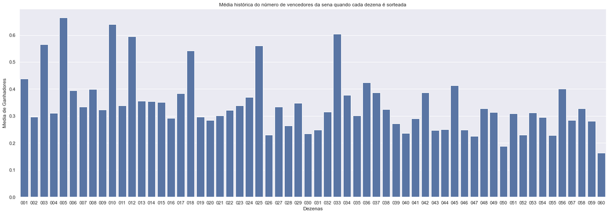

```python
sns.barplot(data=df_sena, x=df_sena['Dezenas'], y=df_sena['Media de Ganhadores'], color="C0").set(title='Média histórica do número de vencedores da sena quando cada dezena é sorteada')
```

```
[Text(0.5, 1.0, 'Média histórica do número de vencedores da sena quando cada dezena é sorteada')]
```

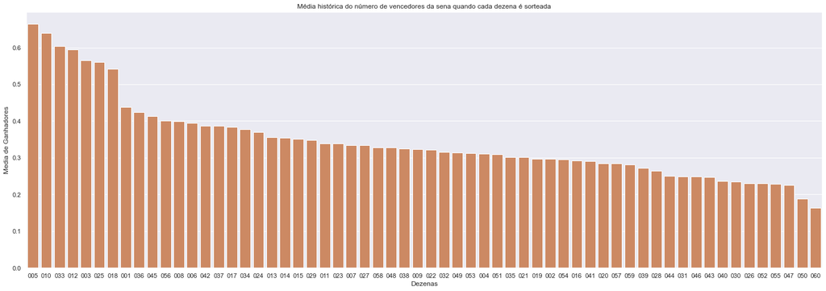

```python
sns.barplot(data=df_sena, x=df_sena['Dezenas'], y=df_sena['Media de Ganhadores'], color="C1", order=df_sena.sort_values(by=['Media de Ganhadores'], ascending=False).set_index('Dezenas').index).set(title='Média histórica do número de vencedores da sena quando cada dezena é sorteada')
```

```python
num_ganhadoras_quina = {}
valores_premios_quina = {}
for resultado in todos_os_resultados:
  quinas_ganhadoras = resultado['quinas']
  premio_quina = resultado['quinas_premio']
  for dezena in resultado['dezenas']:
    num_ganhadoras_quina.setdefault(dezena,[])
    num_ganhadoras_quina[dezena].append(quinas_ganhadoras)
    valores_premios_quina.setdefault(dezena,[])
    valores_premios_quina[dezena].append(premio_quina)

media_ganhadores_quina = {}
for dezena in num_ganhadoras_quina:
  media_ganhadores_quina[dezena] = mean(num_ganhadoras_quina[dezena])

media_premios_quina = {}
for dezena in valores_premios_quina:
  media_premios_quina[dezena] = mean(valores_premios_quina[dezena])

df_quina = pd.DataFrame()
dezenas = [f'{dezena:03}' for dezena in range(1,61)]
df_quina['Dezenas'] = dezenas
df_quina['Media de Ganhadores'] = [media_ganhadores_quina[dezena] for dezena in dezenas]
df_quina['Media de Premios'] = [media_premios_quina[dezena] for dezena in dezenas]
```

```
[Text(0.5, 1.0, 'Média histórica do número de vencedores da quina quando cada dezena é sorteada')]
```

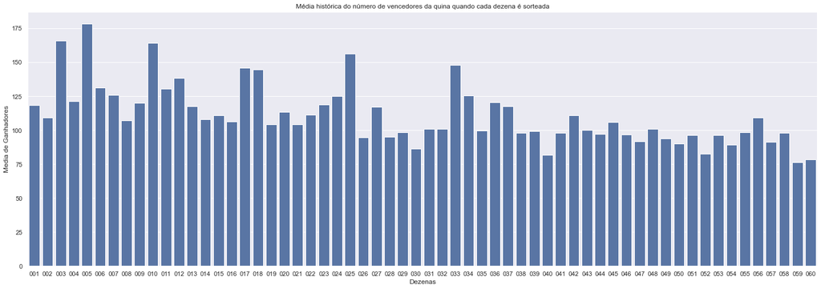

```python
sns.barplot(data=df_quina, x=df_quina['Dezenas'], y=df_quina['Media de Ganhadores'], color="C0").set(title='Média histórica do número de vencedores da quina quando cada dezena é sorteada')
```

```
[Text(0.5, 1.0, 'Média histórica do número de vencedores da quina quando cada dezena é sorteada')]
```

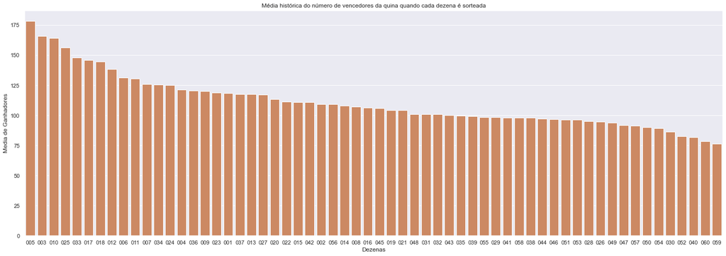

```python
sns.barplot(data=df_quina, x=df_quina['Dezenas'], y=df_quina['Media de Ganhadores'], color="C1", order=df_quina.sort_values(by=['Media de Ganhadores'], ascending=False).set_index('Dezenas').index).set(title='Média histórica do número de vencedores da quina quando cada dezena é sorteada')
```

```python
num_ganhadoras_quadra = {}
valores_premios_quadra = {}
for resultado in todos_os_resultados:
  quadras_ganhadoras = resultado['quadras']
  premio_quadra = resultado['quadras_premio']
  for dezena in resultado['dezenas']:
    num_ganhadoras_quadra.setdefault(dezena,[])
    num_ganhadoras_quadra[dezena].append(quadras_ganhadoras)
    valores_premios_quadra.setdefault(dezena,[])
    valores_premios_quadra[dezena].append(premio_quadra)

media_ganhadores_quadra = {}
for dezena in num_ganhadoras_quadra:
  media_ganhadores_quadra[dezena] = mean(num_ganhadoras_quadra[dezena])

media_premios_quadra = {}
for dezena in valores_premios_quadra:
  media_premios_quadra[dezena] = mean(valores_premios_quadra[dezena])

df_quadra = pd.DataFrame()
dezenas = [f'{dezena:03}' for dezena in range(1,61)]
df_quadra['Dezenas'] = dezenas
df_quadra['Media de Ganhadores'] = [media_ganhadores_quadra[dezena] for dezena in dezenas]
df_quadra['Media de Premios'] = [media_premios_quadra[dezena] for dezena in dezenas]
```

```
[Text(0.5, 1.0, 'Média histórica do número de vencedores da quadra quando cada dezena é sorteada')]
```

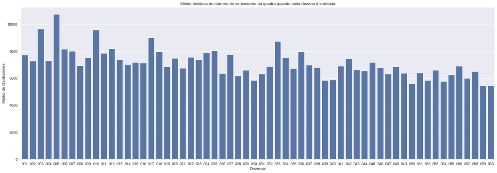

```python
sns.barplot(data=df_quadra, x=df_quadra['Dezenas'], y=df_quadra['Media de Ganhadores'], color="C0").set(title='Média histórica do número de vencedores da quadra quando cada dezena é sorteada')
```

```
[Text(0.5, 1.0, 'Média histórica do número de vencedores da quadra quando cada dezena é sorteada')]
```

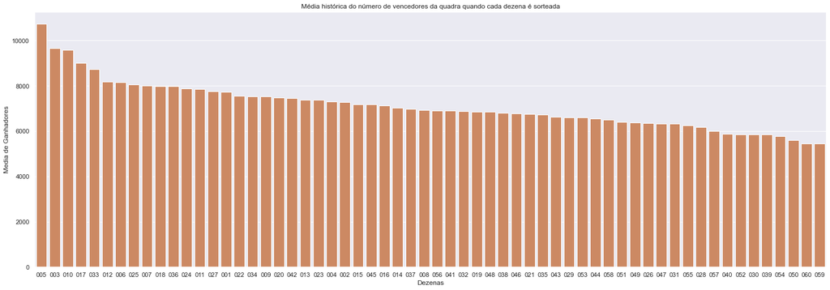

```python
sns.barplot(data=df_quadra, x=df_quadra['Dezenas'], y=df_quadra['Media de Ganhadores'], color="C1", order=df_quadra.sort_values(by=['Media de Ganhadores'], ascending=False).set_index('Dezenas').index).set(title='Média histórica do número de vencedores da quadra quando cada dezena é sorteada')
```

# Tabela com `número médio de ganhadores por sorteio` e `valor médio do prêmio por sorteio` para sena, quina e quadra por dezena sorteada

```python
df_media_ganhadores = pd.DataFrame()
dezenas = [f'{dezena:03}' for dezena in range(1,61)]
df_media_ganhadores['Dezenas'] = dezenas
df_media_ganhadores['Media de Ganhadores Sena'] = df_sena['Media de Ganhadores']
df_media_ganhadores['Media de Ganhadores Quina'] = df_quina['Media de Ganhadores']
df_media_ganhadores['Media de Ganhadores Quadra'] = df_quadra['Media de Ganhadores']
df_media_ganhadores['Media de Premios Sena'] = df_sena['Media de Premios']
df_media_ganhadores['Media de Premios Quina'] = df_quina['Media de Premios']
df_media_ganhadores['Media de Premios Quadra'] = df_quadra['Media de Premios']
df_media_ganhadores
```

|  | Dezenas | Media de Ganhadores Sena | Media de Ganhadores Quina | Media de Ganhadores Quadra | Media de Premios Sena | Media de Premios Quina | Media de Premios Quadra |
| --- | --- | --- | --- | --- | --- | --- | --- |
| 0 | 001 | 0.438298 | 118.459574 | 7741.612766 | 5.873145e+06 | 25553.835277 | 432.775872 |
| 1 | 002 | 0.297189 | 109.257028 | 7266.554217 | 3.363846e+06 | 23644.733213 | 423.337711 |
| 2 | 003 | 0.564444 | 165.755556 | 9660.373333 | 6.537903e+06 | 20607.045333 | 368.668133 |
| 3 | 004 | 0.310606 | 121.390152 | 7291.068182 | 4.910778e+06 | 23366.199886 | 406.097727 |
| 4 | 005 | 0.664179 | 178.242537 | 10734.716418 | 6.428188e+06 | 18397.157239 | 332.799403 |
| 5 | 006 | 0.395161 | 131.391129 | 8151.991935 | 6.368865e+06 | 23826.792460 | 427.316532 |
| 6 | 007 | 0.334764 | 126.051502 | 7998.918455 | 5.021779e+06 | 21583.708670 | 376.587039 |
| 7 | 008 | 0.398374 | 107.146341 | 6938.837398 | 5.856421e+06 | 22501.555203 | 405.323008 |
| 8 | 009 | 0.323144 | 120.209607 | 7524.353712 | 4.814645e+06 | 24054.276245 | 442.768952 |
| 9 | 010 | 0.638989 | 164.079422 | 9576.660650 | 6.438906e+06 | 24079.690433 | 421.880181 |
| 10 | 011 | 0.338583 | 130.409449 | 7853.535433 | 5.525771e+06 | 24754.477087 | 446.906811 |
| 11 | 012 | 0.594937 | 138.185654 | 8184.341772 | 5.779365e+06 | 21742.974262 | 383.600633 |
| 12 | 013 | 0.356275 | 117.469636 | 7381.979757 | 3.408046e+06 | 18290.078421 | 341.058866 |
| 13 | 014 | 0.353712 | 107.965066 | 7032.912664 | 5.438817e+06 | 24440.223799 | 445.454716 |
| 14 | 015 | 0.350711 | 110.933649 | 7181.748815 | 5.292729e+06 | 23059.667962 | 405.282938 |
| 15 | 016 | 0.291339 | 106.173228 | 7137.834646 | 4.690306e+06 | 25393.547795 | 440.254016 |
| 16 | 017 | 0.383399 | 145.972332 | 9020.774704 | 5.533281e+06 | 21391.433794 | 383.262806 |
| 17 | 018 | 0.541667 | 144.500000 | 7987.187500 | 4.298260e+06 | 23791.666542 | 426.336917 |
| 18 | 019 | 0.297414 | 104.370690 | 6863.142241 | 4.049704e+06 | 22720.057802 | 412.227845 |
| 19 | 020 | 0.285106 | 113.178723 | 7488.561702 | 5.945184e+06 | 29614.727957 | 510.714468 |
| 20 | 021 | 0.301435 | 104.291866 | 6742.282297 | 3.568899e+06 | 26872.239234 | 450.714115 |
| 21 | 022 | 0.320930 | 111.455814 | 7548.990698 | 5.178338e+06 | 27043.445209 | 462.960419 |
| 22 | 023 | 0.338462 | 118.742308 | 7370.988462 | 5.856000e+06 | 22394.193923 | 405.006308 |
| 23 | 024 | 0.369048 | 125.218254 | 7892.150794 | 5.481937e+06 | 20651.169643 | 373.866667 |
| 24 | 025 | 0.559829 | 156.269231 | 8065.803419 | 4.364585e+06 | 23406.346026 | 428.888034 |
| 25 | 026 | 0.230392 | 94.666667 | 6349.882353 | 5.331227e+06 | 28994.317206 | 498.244314 |
| 26 | 027 | 0.334615 | 117.315385 | 7756.615385 | 5.891286e+06 | 23893.646269 | 435.571231 |
| 27 | 028 | 0.263566 | 95.104651 | 6179.724806 | 4.608671e+06 | 26229.472519 | 456.128721 |
| 28 | 029 | 0.347656 | 98.386719 | 6610.636719 | 5.587758e+06 | 26706.268789 | 463.376875 |
| 29 | 030 | 0.234615 | 86.361538 | 5847.753846 | 3.756262e+06 | 29892.893577 | 527.217923 |
| 30 | 031 | 0.248908 | 100.698690 | 6313.462882 | 2.132910e+06 | 29924.904672 | 498.510175 |
| 31 | 032 | 0.316000 | 100.676000 | 6865.216000 | 4.373324e+06 | 27689.623360 | 471.064280 |
| 32 | 033 | 0.604563 | 148.091255 | 8732.068441 | 5.252315e+06 | 22728.899506 | 401.081369 |
| 33 | 034 | 0.377432 | 125.249027 | 7525.661479 | 4.504082e+06 | 26390.480000 | 465.174669 |
| 34 | 035 | 0.301961 | 99.749020 | 6737.086275 | 4.107084e+06 | 27250.670471 | 482.969294 |
| 35 | 036 | 0.424603 | 120.527778 | 7980.170635 | 5.856389e+06 | 25855.692500 | 455.162103 |
| 36 | 037 | 0.386364 | 117.636364 | 6971.977273 | 4.436052e+06 | 27185.194129 | 471.401023 |
| 37 | 038 | 0.325397 | 97.785714 | 6810.424603 | 6.205355e+06 | 29351.229841 | 491.570159 |
| 38 | 039 | 0.271552 | 99.120690 | 5838.047414 | 5.966383e+06 | 30209.389009 | 524.718750 |
| 39 | 040 | 0.236052 | 81.673820 | 5875.922747 | 4.421108e+06 | 33527.919356 | 555.141888 |
| 40 | 041 | 0.290196 | 98.109804 | 6892.960784 | 5.601725e+06 | 31846.863725 | 519.688745 |
| 41 | 042 | 0.387218 | 110.695489 | 7452.695489 | 6.878693e+06 | 26378.700977 | 463.668271 |
| 42 | 043 | 0.247059 | 100.023529 | 6624.203922 | 4.771065e+06 | 27946.568510 | 468.184510 |
| 43 | 044 | 0.250980 | 97.043137 | 6560.176471 | 3.191777e+06 | 28201.742275 | 477.624706 |
| 44 | 045 | 0.412766 | 106.055319 | 7168.689362 | 5.540842e+06 | 27914.984553 | 476.736511 |
| 45 | 046 | 0.247934 | 96.619835 | 6772.727273 | 4.641410e+06 | 29791.296860 | 498.036322 |
| 46 | 047 | 0.225108 | 91.683983 | 6321.554113 | 2.965169e+06 | 25937.273463 | 439.476667 |
| 47 | 048 | 0.327434 | 100.734513 | 6842.845133 | 6.174731e+06 | 30049.120310 | 494.605929 |
| 48 | 049 | 0.313253 | 93.767068 | 6379.317269 | 5.271175e+06 | 28222.185622 | 473.438353 |
| 49 | 050 | 0.187500 | 89.900000 | 5602.208333 | 3.141397e+06 | 31638.446542 | 523.019167 |
| 50 | 051 | 0.309524 | 96.468254 | 6394.357143 | 3.003373e+06 | 27178.978532 | 454.742937 |
| 51 | 052 | 0.229508 | 82.532787 | 5860.241803 | 4.270533e+06 | 29245.189057 | 498.043115 |
| 52 | 053 | 0.311828 | 96.283154 | 6607.867384 | 4.831023e+06 | 29312.056846 | 493.942007 |
| 53 | 054 | 0.294574 | 89.259690 | 5763.554264 | 4.681569e+06 | 28377.033256 | 472.366124 |
| 54 | 055 | 0.228155 | 98.533981 | 6242.951456 | 4.687993e+06 | 30276.582379 | 497.543155 |
| 55 | 056 | 0.400810 | 109.012146 | 6908.392713 | 4.930496e+06 | 27229.061093 | 470.370040 |
| 56 | 057 | 0.284483 | 91.357759 | 6002.961207 | 4.986031e+06 | 28164.384353 | 483.453060 |
| 57 | 058 | 0.327731 | 97.957983 | 6493.109244 | 5.686048e+06 | 29633.623319 | 500.079580 |
| 58 | 059 | 0.281385 | 76.316017 | 5449.073593 | 3.667824e+06 | 29303.409913 | 487.762684 |
| 59 | 060 | 0.163793 | 78.353448 | 5452.353448 | 2.486389e+06 | 29400.275086 | 498.193966 |

# 10 Dezenas com as menores médias de vencedores por sorteio:

### Sena:

`['060', '050', '047', '055', '052', '026', '030', '040', '043', '046']`

### Quina:

`['059', '060', '040', '052', '030', '054', '050', '057', '047', '049']`

### Quadra:

`['059', '060', '050', '054', '039', '030', '052', '040', '057', '028']`

```python
list(df_media_ganhadores.sort_values(by=['Media de Ganhadores Sena']).head(10)['Dezenas'])
```

```
['060', '050', '047', '055', '052', '026', '030', '040', '043', '046']
```

```python
list(df_media_ganhadores.sort_values(by=['Media de Ganhadores Quina']).head(10)['Dezenas'])
```

```
['059', '060', '040', '052', '030', '054', '050', '057', '047', '049']
```

```python
list(df_media_ganhadores.sort_values(by=['Media de Ganhadores Quadra']).head(10)['Dezenas'])
```

```
['059', '060', '050', '054', '039', '030', '052', '040', '057', '028']
```

# Média de vencedores por dezena sorteada nas megas da virada

## Só por curiosidade mesmo, já que foram apenas 12 edições

```
[Text(0.5, 1.0, 'Média do número de vencedores da sena quando cada dezena é sorteada na mega da virada')]
```

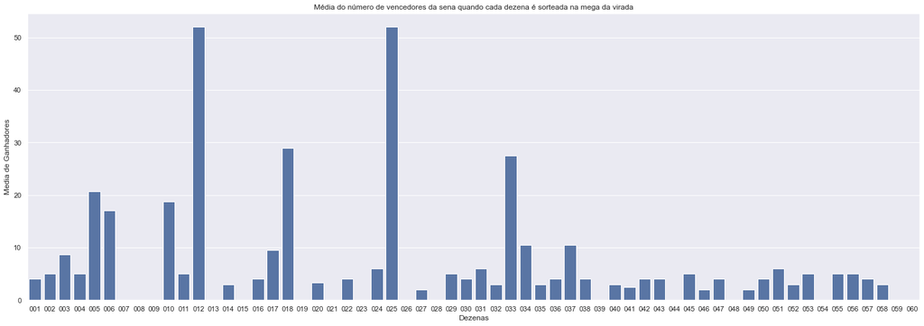

```python
num_ganhadoras_sena_virada = {}
for resultado in resultados_megas_virada:
  senas_ganhadoras = resultado['senas']
  for dezena in resultado['dezenas']:
    num_ganhadoras_sena_virada.setdefault(dezena,[])
    num_ganhadoras_sena_virada[dezena].append(senas_ganhadoras)

media_ganhadores_sena = {}
for dezena in num_ganhadoras_sena_virada:
  media_ganhadores_sena[dezena] = mean(num_ganhadoras_sena_virada[dezena])


df_sena_virada = pd.DataFrame()
dezenas = [f'{dezena:03}' for dezena in range(1,61)]
df_sena_virada['Dezenas'] = dezenas
df_sena_virada['Media de Ganhadores'] = [media_ganhadores_sena[dezena] if dezena in media_ganhadores_sena else 0 for dezena in dezenas]

sns.barplot(data=df_sena_virada, x=df_sena_virada['Dezenas'], y=df_sena_virada['Media de Ganhadores'], color="C0").set(title='Média do número de vencedores da sena quando cada dezena é sorteada na mega da virada')
```

```
[Text(0.5, 1.0, 'Média do número de vencedores da sena quando cada dezena é sorteada na mega da virada')]
```

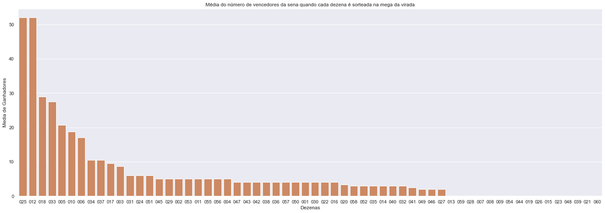

```python
sns.barplot(data=df_sena_virada, x=df_sena_virada['Dezenas'], y=df_sena_virada['Media de Ganhadores'], color="C1", order=df_sena_virada.sort_values(by=['Media de Ganhadores'], ascending=False).set_index('Dezenas').index).set(title='Média do número de vencedores da sena quando cada dezena é sorteada na mega da virada')
```

```
[Text(0.5, 1.0, 'Média do número de vencedores da quina quando cada dezena é sorteada na mega da virada')]
```

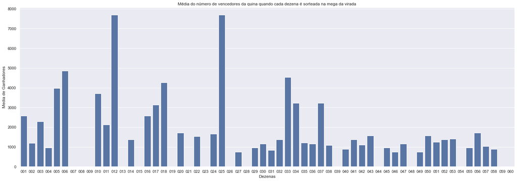

```python
num_ganhadoras_quina_virada = {}
for resultado in resultados_megas_virada:
  quinas_ganhadoras = resultado['quinas']
  for dezena in resultado['dezenas']:
    num_ganhadoras_quina_virada.setdefault(dezena,[])
    num_ganhadoras_quina_virada[dezena].append(quinas_ganhadoras)

media_ganhadores_quina = {}
for dezena in num_ganhadoras_quina_virada:
  media_ganhadores_quina[dezena] = mean(num_ganhadoras_quina_virada[dezena])


df_quina_virada = pd.DataFrame()
dezenas = [f'{dezena:03}' for dezena in range(1,61)]
df_quina_virada['Dezenas'] = dezenas
df_quina_virada['Media de Ganhadores'] = [media_ganhadores_quina[dezena] if dezena in media_ganhadores_quina else 0 for dezena in dezenas]

sns.barplot(data=df_quina_virada, x=df_quina_virada['Dezenas'], y=df_quina_virada['Media de Ganhadores'], color="C0").set(title='Média do número de vencedores da quina quando cada dezena é sorteada na mega da virada')
```

```
[Text(0.5, 1.0, 'Média do número de vencedores da quina quando cada dezena é sorteada na mega da virada')]
```

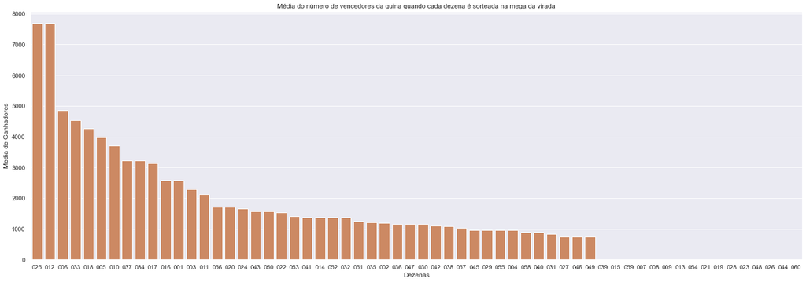

```python
sns.barplot(data=df_quina_virada, x=df_quina_virada['Dezenas'], y=df_quina_virada['Media de Ganhadores'], color="C1", order=df_quina_virada.sort_values(by=['Media de Ganhadores'], ascending=False).set_index('Dezenas').index).set(title='Média do número de vencedores da quina quando cada dezena é sorteada na mega da virada')
```

```
[Text(0.5, 1.0, 'Média do número de vencedores da quadra quando cada dezena é sorteada na mega da virada')]
```

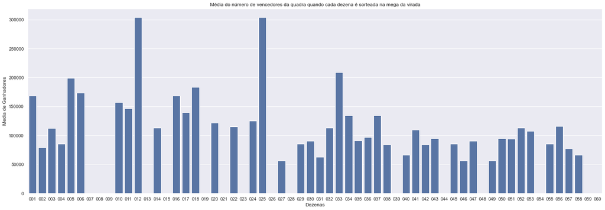

```python
num_ganhadoras_quadra_virada = {}
for resultado in resultados_megas_virada:
  quadras_ganhadoras = resultado['quadras']
  for dezena in resultado['dezenas']:
    num_ganhadoras_quadra_virada.setdefault(dezena,[])
    num_ganhadoras_quadra_virada[dezena].append(quadras_ganhadoras)

media_ganhadores_quadra = {}
for dezena in num_ganhadoras_quadra_virada:
  media_ganhadores_quadra[dezena] = mean(num_ganhadoras_quadra_virada[dezena])


df_quadra_virada = pd.DataFrame()
dezenas = [f'{dezena:03}' for dezena in range(1,61)]
df_quadra_virada['Dezenas'] = dezenas
df_quadra_virada['Media de Ganhadores'] = [media_ganhadores_quadra[dezena] if dezena in media_ganhadores_quadra else 0 for dezena in dezenas]

sns.barplot(data=df_quadra_virada, x=df_quadra_virada['Dezenas'], y=df_quadra_virada['Media de Ganhadores'], color="C0").set(title='Média do número de vencedores da quadra quando cada dezena é sorteada na mega da virada')
```

```
[Text(0.5, 1.0, 'Média do número de vencedores da quadra quando cada dezena é sorteada na mega da virada')]
```

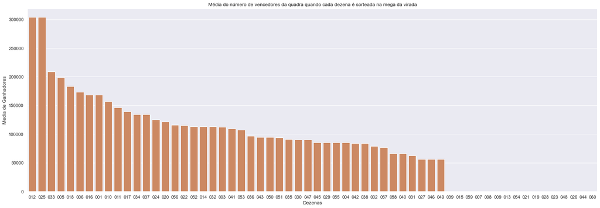

```python
sns.barplot(data=df_quadra_virada, x=df_quadra_virada['Dezenas'], y=df_quadra_virada['Media de Ganhadores'], color="C1", order=df_quadra_virada.sort_values(by=['Media de Ganhadores'], ascending=False).set_index('Dezenas').index).set(title='Média do número de vencedores da quadra quando cada dezena é sorteada na mega da virada')
```

# Média do prêmio para cada dezena sorteada

## Também mais por curiosidade já que os valores acumulados variam bastante

```
[Text(0.5, 1.0, 'Média histórica do premio para vencedores da sena quando cada dezena é sorteada'),
```

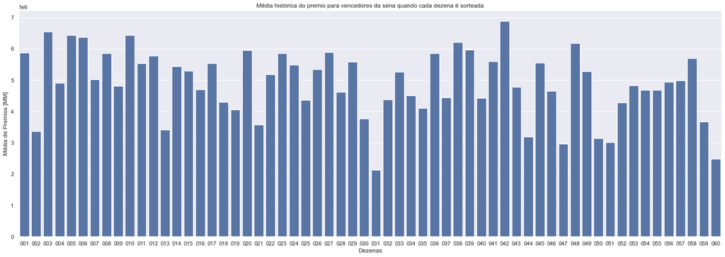

```python
sns.barplot(data=df_sena, x=df_sena['Dezenas'], y=df_sena['Media de Premios'], color="C0").set(title='Média histórica do premio para vencedores da sena quando cada dezena é sorteada', ylabel='Média de Premios [MM]')
```

```
[Text(0.5, 1.0, 'Média histórica do premio para vencedores da sena quando cada dezena é sorteada'),
```

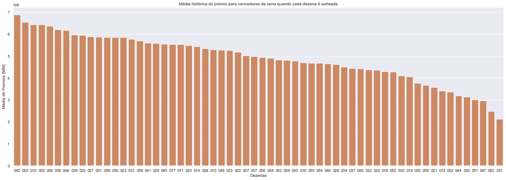

```python
sns.barplot(data=df_sena, x=df_sena['Dezenas'], y=df_sena['Media de Premios'], color="C1", order=df_sena.sort_values(by=['Media de Premios'], ascending=False).set_index('Dezenas').index).set(title='Média histórica do premio para vencedores da sena quando cada dezena é sorteada', ylabel='Média de Premios [MM]')
```

```
[Text(0.5, 1.0, 'Média histórica do premio para vencedores da quina quando cada dezena é sorteada'),
```

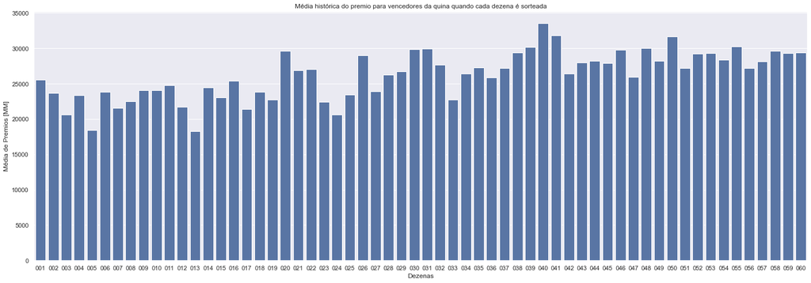

```python
sns.barplot(data=df_quina, x=df_quina['Dezenas'], y=df_quina['Media de Premios'], color="C0").set(title='Média histórica do premio para vencedores da quina quando cada dezena é sorteada', ylabel='Média de Premios [MM]')
```

```
[Text(0.5, 1.0, 'Média histórica do premio para vencedores da quina quando cada dezena é sorteada'),
```

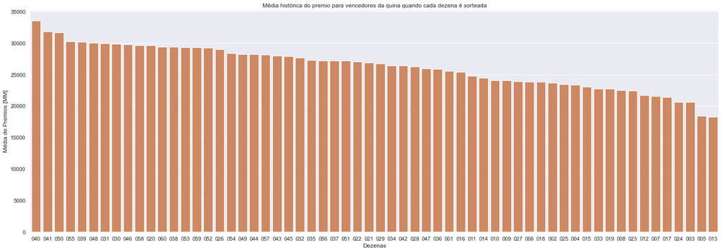

```python
sns.barplot(data=df_quina, x=df_quina['Dezenas'], y=df_quina['Media de Premios'], color="C1", order=df_quina.sort_values(by=['Media de Premios'], ascending=False).set_index('Dezenas').index).set(title='Média histórica do premio para vencedores da quina quando cada dezena é sorteada', ylabel='Média de Premios [MM]')
```

```
[Text(0.5, 1.0, 'Média histórica do premio para vencedores da quadra quando cada dezena é sorteada'),
```

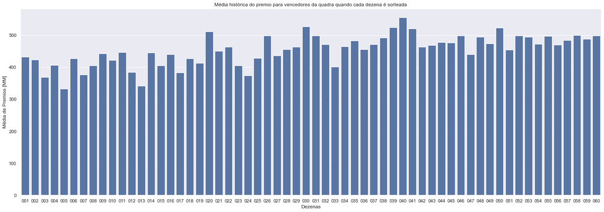

```python
sns.barplot(data=df_quadra, x=df_quadra['Dezenas'], y=df_quadra['Media de Premios'], color="C0").set(title='Média histórica do premio para vencedores da quadra quando cada dezena é sorteada', ylabel='Média de Premios [MM]')
```

```
[Text(0.5, 1.0, 'Média histórica do premio para vencedores da quadra quando cada dezena é sorteada'),
```

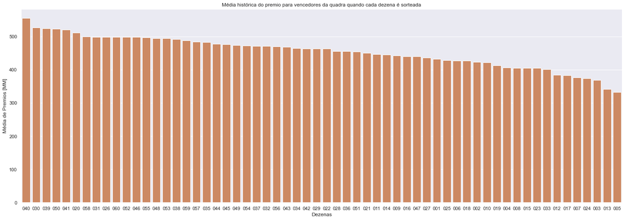

```python
sns.barplot(data=df_quadra, x=df_quadra['Dezenas'], y=df_quadra['Media de Premios'], color="C1", order=df_quadra.sort_values(by=['Media de Premios'], ascending=False).set_index('Dezenas').index).set(title='Média histórica do premio para vencedores da quadra quando cada dezena é sorteada', ylabel='Média de Premios [MM]')
```